# Data Science and Business Analytics Intern @ The Sparks Foundation

# #GRIPOct2021 #TSF

## Problem Statement - Perform exploratory data analysis on dataset of a retail store.

### **Dataset - https://bit.ly/3i4rbWl**

```python
import numpy as np
import pandas as pd
import matplotlib.pyplot as mpl
import seaborn as sns
import warnings
warnings.filterwarnings('ignore')
```

```python
df=pd.read_csv("SampleSuperstore.csv")
df.head()
```

|  | Ship Mode | Segment | Country | City | State | Postal Code | Region | Category | Sub-Category | Sales | Quantity | Discount | Profit |
| --- | --- | --- | --- | --- | --- | --- | --- | --- | --- | --- | --- | --- | --- |
| 0 | Second Class | Consumer | United States | Henderson | Kentucky | 42420 | South | Furniture | Bookcases | 261.9600 | 2 | 0.00 | 41.9136 |
| 1 | Second Class | Consumer | United States | Henderson | Kentucky | 42420 | South | Furniture | Chairs | 731.9400 | 3 | 0.00 | 219.5820 |
| 2 | Second Class | Corporate | United States | Los Angeles | California | 90036 | West | Office Supplies | Labels | 14.6200 | 2 | 0.00 | 6.8714 |
| 3 | Standard Class | Consumer | United States | Fort Lauderdale | Florida | 33311 | South | Furniture | Tables | 957.5775 | 5 | 0.45 | -383.0310 |
| 4 | Standard Class | Consumer | United States | Fort Lauderdale | Florida | 33311 | South | Office Supplies | Storage | 22.3680 | 2 | 0.20 | 2.5164 |

```python
df.info()
```

```
<class 'pandas.core.frame.DataFrame'>
RangeIndex: 9994 entries, 0 to 9993
Data columns (total 13 columns):
 #   Column        Non-Null Count  Dtype
---  ------        --------------  -----
 0   Ship Mode     9994 non-null   object
 1   Segment       9994 non-null   object
 2   Country       9994 non-null   object
 3   City          9994 non-null   object
 4   State         9994 non-null   object
 5   Postal Code   9994 non-null   int64
 6   Region        9994 non-null   object
 7   Category      9994 non-null   object
 8   Sub-Category  9994 non-null   object
 9   Sales         9994 non-null   float64
 10  Quantity      9994 non-null   int64
 11  Discount      9994 non-null   float64
 12  Profit        9994 non-null   float64
dtypes: float64(3), int64(2), object(8)
memory usage: 1015.1+ KB
```

```python
df.isnull().sum()
```

```
Ship Mode       0
Segment         0
Country         0
City            0
State           0
Postal Code     0
Region          0
Category        0
Sub-Category    0
Sales           0
Quantity        0
Discount        0
Profit          0
dtype: int64
```

```python
df.columns
```

```
Index(['Ship Mode', 'Segment', 'Country', 'City', 'State', 'Postal Code',
       'Region', 'Category', 'Sub-Category', 'Sales', 'Quantity', 'Discount',
       'Profit'],
      dtype='object')
```

```python
df.shape
```

```
(9994, 13)
```

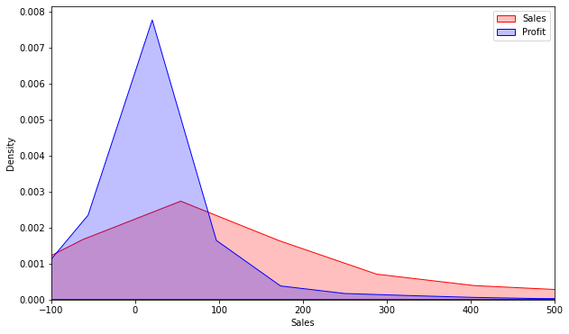

```python
mpl.figure(figsize=(10, 6))
sns.kdeplot(df['Sales'],color='Red',label='Sales',shade=True)
sns.kdeplot(df['Profit'],color='Blue',label='Profit',shade=True)
mpl.xlim([-100,500])
mpl.legend()
```

## Analysis using Pairplot of Sales, Quantity and Profit against each other

**1. Based on catagory**

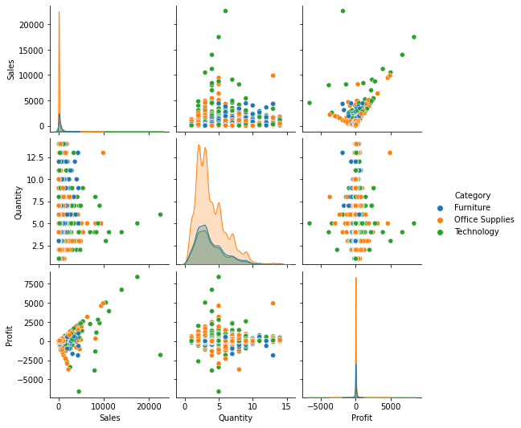

```python
sns.pairplot(df,hue='Category', vars=['Sales', 'Quantity', 'Profit'])
```

- This 3x3 matrix plot helps us understand the distribution of sales, quantity and profit considering the category of the products.

**2. Based on Region**

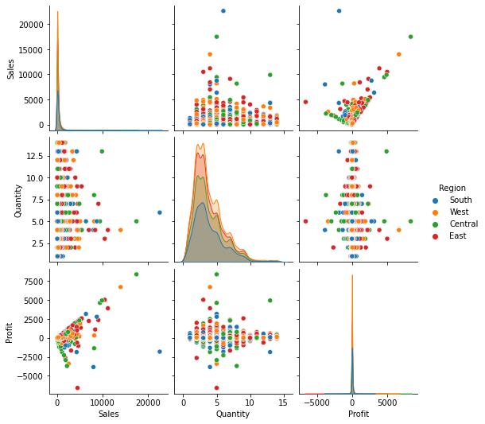

```python
sns.pairplot(df,hue='Region', vars=['Sales', 'Quantity', 'Profit'])
```

- This 3x3 matrix plot helps us understand the distribution of sales, quantity and profit considering the region of deals.

**3. Based on the segment**

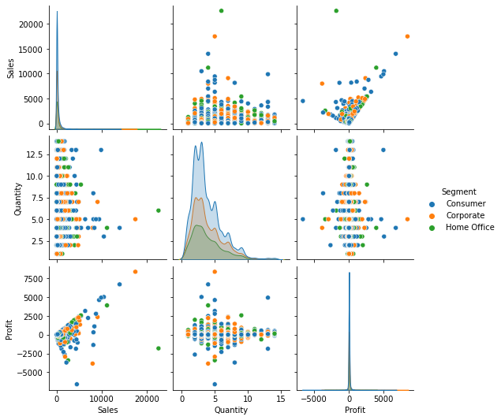

```python
sns.pairplot(df,hue='Segment', vars=['Sales', 'Quantity', 'Profit'])
```

- This 3x3 matrix plot helps us understand the distribution of sales, quantity and profit considering the segment.

## Correlation Matrix

```python
df.corr(method='pearson')
```

|  | Postal Code | Sales | Quantity | Discount | Profit |
| --- | --- | --- | --- | --- | --- |
| Postal Code | 1.000000 | -0.023854 | 0.012761 | 0.058443 | -0.029961 |
| Sales | -0.023854 | 1.000000 | 0.200795 | -0.028190 | 0.479064 |
| Quantity | 0.012761 | 0.200795 | 1.000000 | 0.008623 | 0.066253 |
| Discount | 0.058443 | -0.028190 | 0.008623 | 1.000000 | -0.219487 |
| Profit | -0.029961 | 0.479064 | 0.066253 | -0.219487 | 1.000000 |

## Heatmap for Correlation

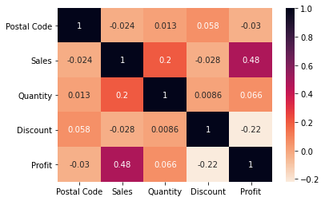

```python
sns.heatmap(df.corr(method='pearson'),cmap='rocket_r',annot=True)
```

From above Heatmap, we get -

- Sales and Profit are a bit correlated.
- Discount and Profit are negatively correlated
- Quantity and Profit are less moderately correlated.

## Count plot of each feature - Shipment Mode, Segment, Region and Category

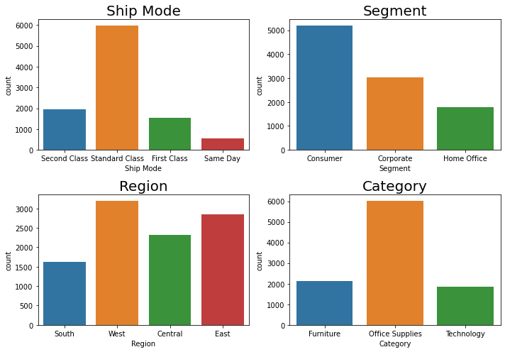

```python
fig,axs=mpl.subplots(nrows=2,ncols=2,figsize=(10,7));

sns.countplot(df['Ship Mode'],ax=axs[0][0])
sns.countplot(df['Segment'],ax=axs[0][1])
sns.countplot(df['Region'],ax=axs[1][0])
sns.countplot(df['Category'],ax=axs[1][1])
axs[0][0].set_title('Ship Mode',fontsize=20)
axs[0][1].set_title('Segment',fontsize=20)
axs[1][0].set_title('Region',fontsize=20)
axs[1][1].set_title('Category',fontsize=20)


mpl.tight_layout()
```

## Count-wise plot of Sub-Categories

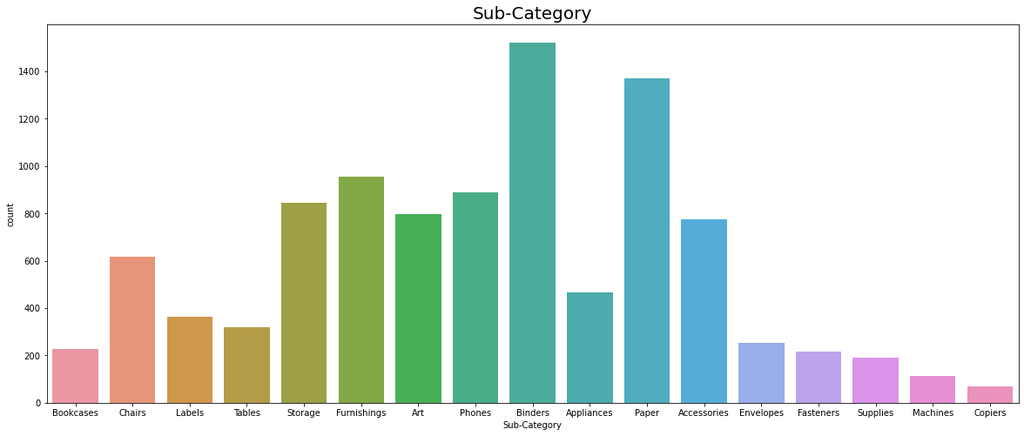

```python
mpl.figure(figsize=(20,8))
sns.countplot(df['Sub-Category'])
mpl.title('Sub-Category',fontsize=20)
```

## Count-wise plot of State

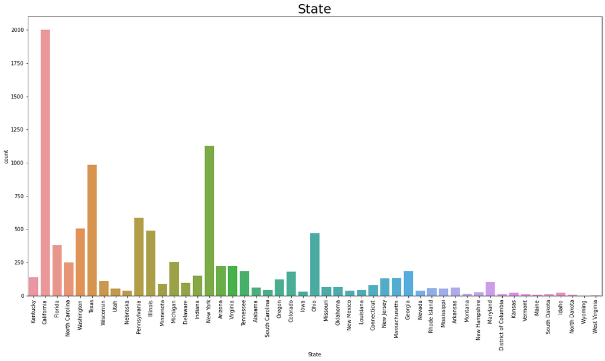

```python
mpl.figure(figsize=(20, 10))
sns.countplot(df['State'])
mpl.xticks(rotation=90)
mpl.title('State',fontsize=25)
```

## Count-wise plot of Discount

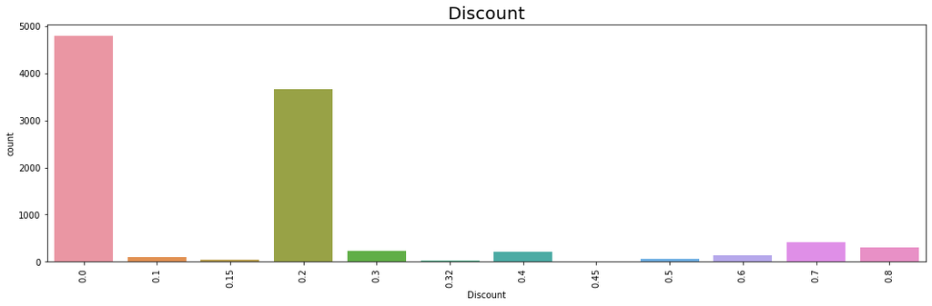

```python
mpl.figure(figsize=(18,5))
sns.countplot(df['Discount'])
mpl.xticks(rotation=90)
mpl.title('Discount',fontsize=20)
```

## Statewise Deal Analysis

```python
df['Country'].value_counts()
```

```
United States    9994
Name: Country, dtype: int64
```

```python
dfstate = df['State'].value_counts()
dfstate.head(15)
```

```
California        2001
New York          1128
Texas              985
Pennsylvania       587
Washington         506
Illinois           492
Ohio               469
Florida            383
Michigan           255
North Carolina     249
Virginia           224
Arizona            224
Georgia            184
Tennessee          183
Colorado           182
Name: State, dtype: int64
```

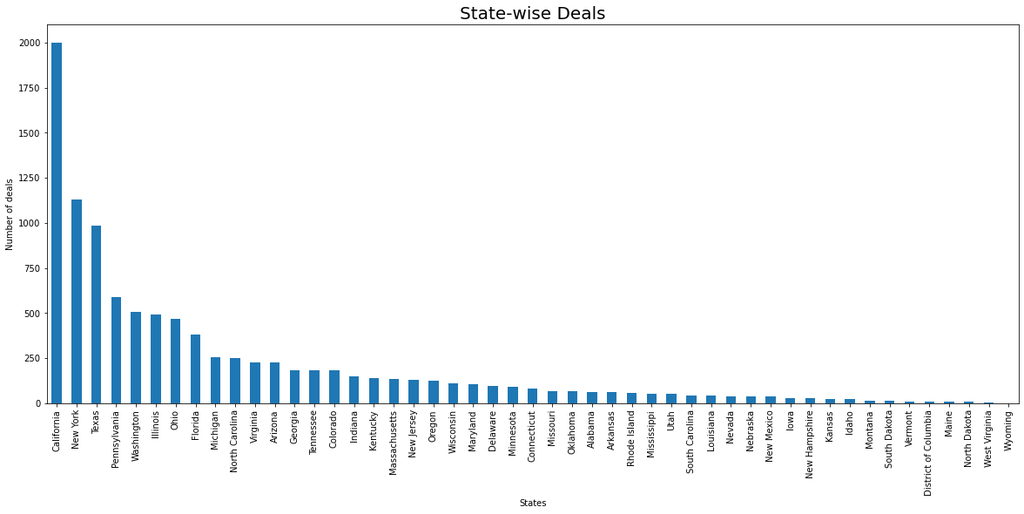

```python
dfstate.plot(kind='bar',figsize=(20,8))
mpl.ylabel('Number of deals')
mpl.xlabel('States')

mpl.title('State-wise Deals', fontsize = 20)
mpl.show()
```

The above plot shows the state-wise count of deals for the store.

- California has the highest number of deals followed by New York and Texas respectively.
- Wyoming has the least number of deals preceeded by West Virginia and North Dakota.

```python
df['State'].value_counts().mean()
```

```
203.9591836734694
```

- Average number of deals per state is 204.